# Part I - Loan Data From Prosper

#### Observations

> 1. 94.7% of the Borrowers were employed.
> 2. 54% of Borrowers are homeowners.
> 3. 99.9% of Borrowers had source of incomes that are verifiable
> 4. Medium Term Loans recorded the highest (67.3%) among the Loan Terms.
> 5. Quarter four (4) had the most borrowing (31%)
> 6. The year 2013 recorded the highest borrowing (45.6%)
> 7. Borrowers within the income range USD 50k - USD 74.9k were the most (31%)
> 8. Borrowers rated C were the most among the other ratings.
> 9. Debt Consolidation recorded the highest purpose for Borrowing

### Identifying distribution of the numerical columns

```python
def histogram(column_name):plt.hist(data=df_Newloan_clean,x=column_name,bins=50)
```

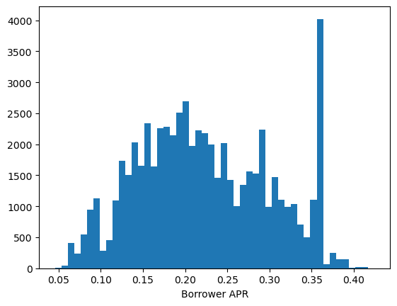

```python
histogram('BorrowerAPR')
plt.xlabel('Borrower APR')
plt.show()
```

```
The maximum Original Loan Amount is 35000
```

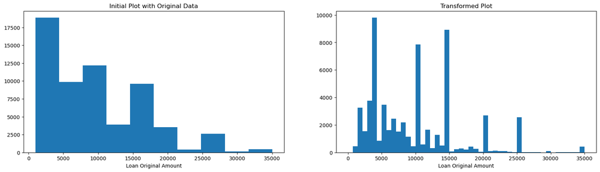

```python
print('The maximum Original Loan Amount is '+ str(df_Newloan_clean.LoanOriginalAmount.max()))

plt.figure(figsize = [20, 5])

# HISTOGRAM ON LEFT: full data without scaling
plt.subplot(1, 2, 1)
plt.hist(data=df_Newloan_clean, x='LoanOriginalAmount');
# Display a label on the x-axis
plt.title('Initial Plot with Original Data')
plt.xlabel('Loan Original Amount')


# HISTOGRAM ON RIGHT
plt.subplot(1, 2, 2)

# Get the ticks for bins between [0 - maximum Loan Original Amount]
bins = np.linspace(0,35000,num=50)
plt.hist(data=df_Newloan_clean, x='LoanOriginalAmount', bins=bins);
plt.title('Transformed Plot')
plt.xlabel('Loan Original Amount')
plt.show()
```

```
The maximum Monthly Loan Payment Amount is 2251.51
```

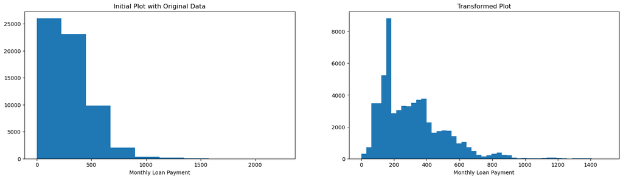

```python
print('The maximum Monthly Loan Payment Amount is '+ str(df_Newloan_clean.MonthlyLoanPayment.max()))

plt.figure(figsize = [20, 5])

# HISTOGRAM ON LEFT: full data without scaling
plt.subplot(1, 2, 1)
plt.hist(data=df_Newloan_clean, x='MonthlyLoanPayment');
# Display Title and Label
plt.title('Initial Plot with Original Data')
plt.xlabel('Monthly Loan Payment')

# HISTOGRAM ON RIGHT
plt.subplot(1, 2, 2)

# Get the ticks for bins between [0 - maximum weight]
bins = np.linspace(0,1500,num=50)
plt.hist(data=df_Newloan_clean, x='MonthlyLoanPayment', bins=bins);
plt.title('Transformed Plot')
plt.xlabel('Monthly Loan Payment')
plt.show()
```

```
The maximum Debt to Income Ration is 10.01
```

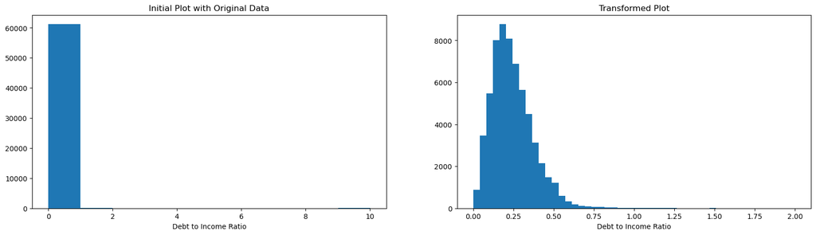

```python
print('The maximum Debt to Income Ration is '+ str(df_Newloan_clean.DebtToIncomeRatio.max()))

plt.figure(figsize = [20, 5])

# HISTOGRAM ON LEFT: full data without scaling
plt.subplot(1, 2, 1)
plt.hist(data=df_Newloan_clean, x='DebtToIncomeRatio');
# Display a label on the x-axis
plt.title('Initial Plot with Original Data')
plt.xlabel('Debt to Income Ratio')


# HISTOGRAM ON RIGHT
plt.subplot(1, 2, 2)

# Get the ticks for bins between [0 - maximum weight]
bins = np.linspace(0,2,num=50)
plt.hist(data=df_Newloan_clean, x='DebtToIncomeRatio', bins=bins);
plt.title('Transformed Plot')
plt.xlabel('Debt to Income Ratio')
plt.show()
```

### Discuss the distribution(s) of your variable(s) of interest. Were there any unusual points? Did you need to perform any transformations?

> 1. Borrowers are postively skewed on Prosper Rating. More than 50% of Borrowers rated C or higher
> 2. Borrowers were postively skewed on Loan Terms. Majority of the Borrowers went for Medium to Long Term loans.
> 3. Although there was difference in number of Borrowers who owned home and those who did not, the difference isn't significantly huge.
> 4. I didn't identify any unsual point regarding my variables of insteres neither did I transform any of the variables.

### Of the features you investigated, were there any unusual distributions? Did you perform any operations on the data to tidy, adjust, or change the form of the data? If so, why did you do this?

> I had unsual distribution on the following variables; Loan Original Amount, Monthly Loan Payment and Debt to Income Ration. I therefore adjusted the ticks of these variables to enable me have a better view of the distribution since the original data didn't show ticks for the bins intervals.

## Bivariate Exploration

### Among Homeowners and Non-homeowners, which recorded the highest number in terms of high Ratings i.e AA - B?

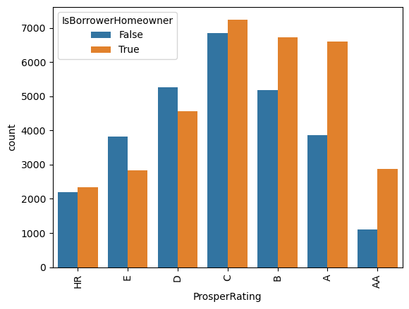

```python
sb.countplot(data = df_Newloan_clean, x = 'ProsperRating', hue = 'IsBorrowerHomeowner')
plt.xticks(rotation=90)
plt.show()
```

### Are Higher Ratings Associated with Higher Income?

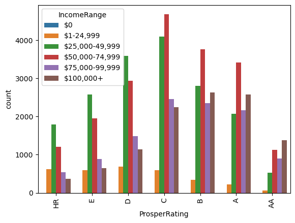

```python
sb.countplot(data = df_Newloan_clean, x = 'ProsperRating', hue = 'IncomeRange')
plt.xticks(rotation=90)

plt.show()
```

#### Observation

> 1. As income increases the number of borrowers with high ratings increases and vice versa.
> 2. It can be observed too that with increase in income, the number of borrowers with low ratings reduces.

### What are the relationships among the numeric variables

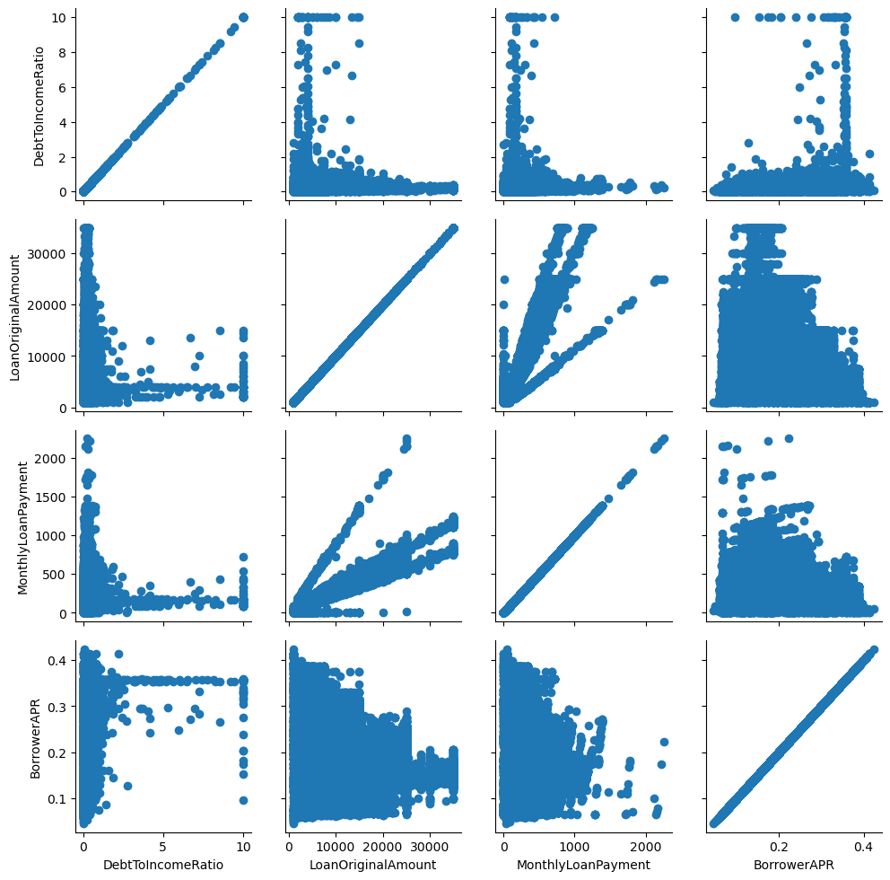

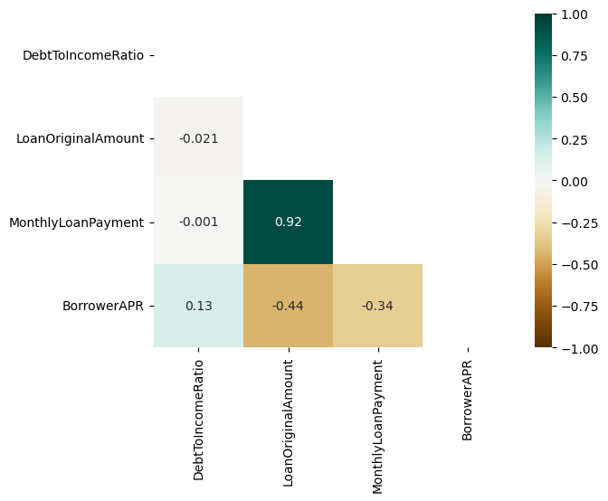

```python
Numeric_Cols=['DebtToIncomeRatio','LoanOriginalAmount','MonthlyLoanPayment','BorrowerAPR']

df = df_Newloan_clean[Numeric_Cols]
g = sb.PairGrid(df)
g.map(plt.scatter);
plt.show()

mask = np.triu(np.ones_like(df_Newloan_clean[Numeric_Cols].corr(), dtype=bool))
sb.heatmap(df_Newloan_clean[Numeric_Cols].corr(),mask=mask,vmin=-1, vmax=1, annot=True, cmap='BrBG')
```